# Plots for covid time series

# Library calls

```r
library(tidyverse)
library(ggplot2)
library(janitor)
library(lubridate)
library(leaflet)
```

# KPIs to explore

- Hospital admissions
- Bed occupancy
- Length of stay
- A&E attendances
- A&E wait times

# Plots to make

A time series line graph, with date along the bottom (month or quarter, tbc), and KPI measure on y-axis. From 2018(or earlier) until now. **requires data cleaning step to convert month/quarter to datetime class**

Including a line for “all health boards” - tbc whether an average or aggregate for the KPI. **requires data wrangling step to make this summary data** *We could make a static plot of all hbs to display alongside an interactive plot to select HBs; such that all HBs is not needed in the input selector.*

With a filter for health board (so we can filter for 1 or multi-select for 1+).

# Hospital admissions

The following three datasets collect data about number of hospital admissions from 2020 to 2023. The number of hospital admissions is here registered weekly. For each of them, we have informations about hb, weekly hospital admissions and average and percentage of hospital admissions during the precovid (period 2018/2019). In addition to that, each of the three files contains informations respectively about demographics of patients, simd quintile and specialty.

```r
ha_demo <- read_csv("../data/covid/hospital_admissions/hospital_admissions_hb_agesex_20230706.csv") %>%
  clean_names()

ha_simd <- read_csv("../data/covid/hospital_admissions/hospital_admissions_hb_simd_20230706.csv") %>%
  clean_names()

ha_specialty <- read_csv("../data/covid/hospital_admissions/hospital_admissions_hb_specialty_20230706.csv") %>%
  clean_names()
```

### Wrangling data operations.

First of all, I create a column called ‘month_ending_date’, which I want have a data format and contains simply the month, in this way I will be able to group the data by month and make the dataset sìconsistent with the other datasets.

```r
ha_demo <- ha_demo %>%
  mutate(month_ending_date = ym(str_sub(as.character(week_ending), start = 1, end = 6)), .after = week_ending) %>%
  mutate(week_ending = ymd(week_ending))


ha_simd <- ha_simd %>%
  mutate(month_ending_date = ym(str_sub(as.character(week_ending), start = 1, end = 6)), .after = week_ending) %>%
  mutate(week_ending = ymd(week_ending))



#Since, the heal board code 'Scotland' correspond to the entire Scotland, I am going to mutate it in 'Scotland' for clarity.




#Finally, I am going to create a new column for dividing the age_groups into different age groups I am more interested in.

ha_demo <- ha_demo %>%
  mutate(age = case_when(

    age_group == "Under 5"~ "Under 5",


    age_group %in% c("15 - 44", "45 - 64")~"5 - 64",


    age_group %in% c("65 - 74", "75 - 84", "85 and over")~"over 65",

    age_group == "5 - 14"~ "5 - 64",


    age_group == "All ages"~"All ages"
  ),


  .after = age_group)
```

```r
ha_demo %>%
  filter(hb %in% c("S08000015", "S92000003")) %>%
  group_by(hb, month_ending_date) %>%
  summarise(mean_admissions = mean(number_admissions)) %>%
  ggplot() +
  aes(x = month_ending_date, y = mean_admissions, group = hb, colour = hb) +
  geom_line()
```

```r
map <- read_csv("../data/cleaned_data/hospital_locations_clean.csv") %>%
  clean_names()
```

```r
ha_demo %>%
  group_by(hb) %>%
  summarise(mean_adm = mean(number_admissions)) %>%
  ggplot() +
  aes(x = hb, y = mean_adm, fill = hb) +
  geom_col()
```

```r
ha_demo %>%
  filter(month_ending_date == "2023-06-01") %>%
  group_by(hb) %>%
  summarise(mean_adm = mean(number_admissions)) %>%
  ggplot() +
  aes(x = hb, y = mean_adm, fill = hb) +
  geom_col()
```

```r
ha_for_join <- ha_demo %>%
  group_by(hb) %>%
  summarise(mean_adm = mean(number_admissions))
```

```r
#join <- left_join(ha_demo, map, by = "hb")
```

```r
join_ha_map <- full_join(map, ha_for_join, by = "hb")
```

#Cleaning join dataset

```r
join_ha_map %>%
leaflet() %>%
  addProviderTiles(providers$Stamen.TonerLite) %>%
  addCircleMarkers(lng = ~ longitude,
                   lat = ~ latitude,
                   weight = 0,
                   fillColor = ~colorNumeric('RdYlGn', mean_adm)
                   (mean_adm),
                   fillOpacity = 0.9
                   #popup = ~ paste( br(), "Board:", HB, br(), round(mean_diff, 0))
  )
```

```r
ha_demo %>%
  arrange(desc(week_ending))
```

```r
ha_simd %>%
  filter(hb %in% c("S08000015")) %>%
  group_by(simd_quintile, month_ending_date) %>%
  summarise(mean_admissions = mean(number_admissions)) %>%
  ggplot() +
  aes(x = month_ending_date, y = mean_admissions, group = simd_quintile, colour = simd_quintile) +
  geom_line()
```

```r
ha_demo %>%
  filter(hb %in% c("S92000003"), age_group != "All ages") %>%
  group_by(age_group, month_ending_date) %>%
  summarise(mean_admissions = mean(number_admissions)) %>%
  ggplot() +
  aes(x = month_ending_date, y = mean_admissions, group = age_group, colour = age_group) +
  geom_line() +
  labs(x = "\nYear",
       y = "average monthly hospital admissions\n")
```

```r
ha_demo %>%
  filter(hb %in% c("S08000015"), age != "All ages") %>%
  group_by(age, month_ending_date) %>%
  summarise(mean_admissions = mean(number_admissions)) %>%
  ggplot() +
  aes(x = month_ending_date, y = mean_admissions, group = age, colour = age) +
  geom_line()
```

Starting point: Chiara work on covid/hospital_admissions data

# Length of stay

Starting point: analyses/naomi_exploring_inpatient.Rmd

```r
# load in data (deprivation - also avail: age/sex, specialty)
inpatients_deprivation <- read_csv("../data/inpatient/inpatient_and_daycase_by_nhs_board_of_treatment_and_simd.csv") %>%
  clean_names() %>%
  mutate(quarter = zoo::as.yearqtr(quarter))

# generate stays data for all health boards to compare individual hbs to
all_hbs_stays <- inpatients_deprivation %>%
  group_by(quarter) %>%
  summarise(stays = sum(stays),
            length_of_stay = sum(length_of_stay),
            average_length_of_stay = length_of_stay / stays) %>%
  mutate(hb = "All health boards", .after = quarter)

# select same columns from original df
stays_per_hb <- inpatients_deprivation %>%
  # check group by
  group_by(hb, quarter) %>%
  summarise(stays = sum(stays),
            length_of_stay = sum(length_of_stay),
            average_length_of_stay = length_of_stay / stays) %>%
  select(quarter, hb, stays, length_of_stay, average_length_of_stay)

# combine all_hbs data with individual hbs data
stays <- bind_rows(all_hbs_stays, stays_per_hb)

# plot ave_length_of_stay over time with hb filter
# assign to plot_ts_length_stay_filter_hb
# note scale all health boards == individual HB so keep on same graph
stays %>%
  # filter for multi-select - replace S08000015 with input selector for hb
  filter(hb %in% c("All health boards","S08000015")) %>%
  ggplot() +
  aes(x = quarter, y = average_length_of_stay, colour = hb) +
  geom_line() +
  geom_point() +
  scale_colour_brewer(type = "qual", palette = "Set1") +
  labs(x = "\nYear quarter", y = "Average length of stay\n",
       title = "Length of stay for inpatients and day cases",
       colour = "Health board") +
  theme(legend.position = "bottom",
        panel.background = element_blank(),
        panel.grid.minor.x = element_blank(),
        panel.grid.minor.y = element_blank(),
        axis.text = element_text(size = 20),
        axis.title = element_text(size = 28),
        legend.title = element_text(size = 28),
        plot.title = element_text(size = 32)
        )
```

# Bed occupancy

Starting point: analyses/thijmen_exploring_beds.Rmd

## plot occupancy hb v scotland on ts

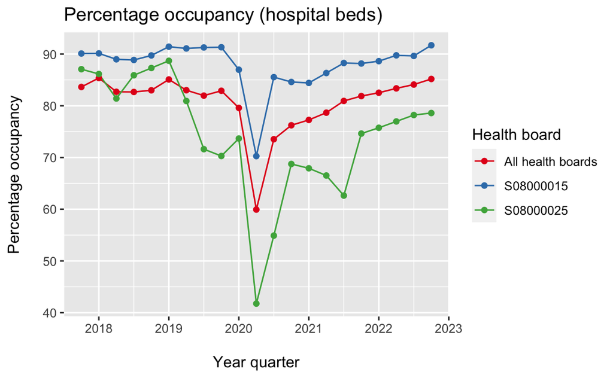

```r
# naomi
# load in data
beds <- read_csv("../data/beds_by_nhs_board_of_treatment_and_specialty.csv") %>%
  clean_names() %>%
  mutate(quarter = zoo::as.yearqtr(quarter))
# generate occupancy data for all health boards to compare individual hbs to
all_hbs_occupancy <- beds %>%
  group_by(quarter) %>%
  summarise(total_occupied_beddays = sum(total_occupied_beddays),
            all_staffed_beddays = sum(all_staffed_beddays)) %>%
  mutate(percentage_occupancy = 100 * (total_occupied_beddays / all_staffed_beddays),
         hb = "All health boards", .after = quarter)

# select same columns from original df
occupancy_per_hb <- beds %>%
  group_by(hb, quarter) %>%
 summarise(total_occupied_beddays = sum(total_occupied_beddays),
            all_staffed_beddays = sum(all_staffed_beddays)) %>%
  mutate(percentage_occupancy = 100 * (total_occupied_beddays / all_staffed_beddays))
# combine all_hbs data with individual hbs data
occupancy <- bind_rows(all_hbs_occupancy, occupancy_per_hb)

# plot ave_length_of_stay over time with hb filter
# assign to plot_ts_occupancy_filter_hb
# note scale all health boards == individual HB so keep on same graph
occupancy %>%
  # filter for multi-select - replace S08000015 with input selector for hb
  filter(hb %in% c("All health boards","S08000015", "S08000025")) %>%
  ggplot() +
  aes(x = quarter, y = percentage_occupancy, colour = hb) +
  geom_line() +
  geom_point() +
  scale_colour_brewer(type = "qual", palette = "Set1") +
  labs(x = "\nYear quarter", y = "Percentage occupancy\n",
       title = "Percentage occupancy (hospital beds)",
       colour = "Health board") #+
```

```r
  # theme(legend.position = "bottom",
  #       panel.background = element_blank(),
  #       panel.grid.minor.x = element_blank(),
  #       panel.grid.minor.y = element_blank(),
  #       axis.text = element_text(size = 20),
  #       axis.title = element_text(size = 28),
  #       legend.title = element_text(size = 28),
  #       plot.title = element_text(size = 32)
  #       )
```

**Interpretation:** bed occupancy differs by health board, e.g. here we can see it is higher than the national average (red, “All health boards”) for health board 15 (blue) and usually lower for health board 25 (green). All health boards see a dip in occupancy in Q2 2020, due to COVID. The return to pre-covid occupancy levels also seems to differ by health board - this is an interesting one to show on the dashboard.

## heatmap for occupancy

- is there hospitals in the data? yes
- need to collapse value for all specialties to get to one value per location; what will “all of scotland” map look like??

```r
library(leaflet)
library(shiny)

 # load in hospitals data
## hospitals for map
hospitals <- read_csv("../data/cleaned_data/hospital_locations_clean.csv")
### colour palette for hospitals on map
pal <- colorFactor(c("navy", "blue", "steelblue", "skyblue",
                     "red","indianred", "maroon", "brown",
                     "springgreen", "springgreen2", "springgreen3", "springgreen4",
                     "gold", "goldenrod", "yellow", "orange"),
                   domain = unique(hospitals$HB))
```

```r
# raw data to use
beds <- read_csv("../data/beds_by_nhs_board_of_treatment_and_specialty.csv") %>%
  clean_names() %>%
  mutate(quarter = zoo::as.yearqtr(quarter))
```

```r
# data prep script for occupancy heatmap
most_recent_quarter <- beds %>%
  arrange(desc(quarter)) %>%
  head(1) %>%
  pull(quarter)

hospitals_lookup <- hospitals %>%
  clean_names() %>%
  select(location, location_name, longitude, latitude)

hospital_occupancy <- beds %>%
  filter(quarter == most_recent_quarter) %>%
  group_by(location, hb) %>%
  summarise(total_occupied_beddays = sum(total_occupied_beddays),
            all_staffed_beddays = sum(all_staffed_beddays)) %>%
  mutate(percentage_occupancy = 100 * (total_occupied_beddays / all_staffed_beddays))
hospital_location_occupancy <- hospital_occupancy %>%
  left_join(hospitals_lookup)
```

```r
# show hospitals on map, currently coloured by hb
hospital_location_occupancy %>%
      filter(hb == "S08000031") %>%
      leaflet() %>%
      addTiles() %>%
      addCircleMarkers(lng = ~ longitude,
                       lat = ~ latitude,
                       weight = 1,
                       popup = ~ paste(location_name, br(), "Board:", hb),
                       color = ~ percentage_occupancy
      )
```

[interactive chart not shown]

# A&E attendances

Starting point: one of Naomi’s notebooks from Tuesday AM

# A&E wait times

Starting point: one of Chiara/Thijmen’s notebooks from Monday